# COVID-19 Image Classification

**Data Description**

You are provided with a training set and a test set of images of 3 classes. Each image has a filename that is its unique id. The dataset comprises 3 classes: COVID-19, Viral Pneumonia, and Normal. The goal of the project is to create a classifier capable of determining the class of the X-ray image.

**Dataset**

The data provided is included into 4 different files:

- testimage.npy
- testlabels.csv
- trainimage.npy
- trainlables.csv

**Context**

Can you differentiate an X-ray image of a normal person from an unhealthy one? The ability to do so can mean a better diagnosis.

**Brandon Smith 2-25-2021** Make up project due to being out sick

**Import Libraries**

```python
# Import the needed libraries
%matplotlib inline
import math
import numpy as np
import pandas as pd
from glob import glob
from zipfile import ZipFile
import seaborn as sns

import tensorflow as tf
from tensorflow.keras import datasets, models, layers, optimizers
from tensorflow.keras.preprocessing.image import ImageDataGenerator
from tensorflow.keras.callbacks import ModelCheckpoint, EarlyStopping
from tensorflow.keras.optimizers import RMSprop, Adam
from keras.utils.np_utils import to_categorical
from google.colab.patches import cv2_imshow

from matplotlib import pyplot as plt
import cv2
from sklearn.preprocessing import LabelBinarizer
from sklearn.model_selection import train_test_split
from sklearn.metrics import confusion_matrix
```

```python
# Mount Google Drive
from google.colab import drive
from google.colab import files
drive.mount('/content/gdrive')
print(tf.__version__)
```

**Import the Data**

```python
# Import the data from the dataset zip (labels/csv)
test_labels = pd.read_csv('/content/gdrive/My Drive/Colab Notebooks/testLabels.csv')
train_labels = pd.read_csv('/content/gdrive/My Drive/Colab Notebooks/trainLabels.csv')
```

```python
print(test_labels)
```

```
              Label
0   Viral Pneumonia
1   Viral Pneumonia
2   Viral Pneumonia
3   Viral Pneumonia
4   Viral Pneumonia
..              ...
61           Normal
62           Normal
63           Normal
64           Normal
65           Normal

[66 rows x 1 columns]
```

```python
# Import the data from the dataset zip (images/npy)
test_images = np.load('/content/gdrive/My Drive/Colab Notebooks/ComputerVision/testimage.npy')
train_images = np.load('/content/gdrive/My Drive/Colab Notebooks/ComputerVision/trainimage.npy')
```

```python
# Evaluate the training -> testing percentage to verify that we have enough of each to hit a 20-30% testing set compared to training set
print(test_images.shape)
print(train_images.shape)
```

```
(66, 128, 128, 3)
(251, 128, 128, 3)
```

**Explore the Data**

```python
# Print value counts of lables in the training dataset
print(train_labels['Label'].value_counts())
```

```
Covid              111
Normal              70
Viral Pneumonia     70
Name: Label, dtype: int64
```

```python
# Print value counts of labels in the testing dataset
print(test_labels['Label'].value_counts())
```

```
Covid              26
Normal             20
Viral Pneumonia    20
Name: Label, dtype: int64
```

```python
# Find unique labels in training labels
print(train_labels.Label.unique())
```

```
['Viral Pneumonia' 'Covid' 'Normal']
```

```python
# Find unique labels in test labels
print(test_labels.Label.unique())
```

```
['Viral Pneumonia' 'Covid' 'Normal']
```

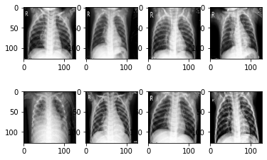

```python
# Show sample images in training images
for i in range(8):
  plt.subplot(2,4,i+1)
  plt.imshow(train_images[i])
```

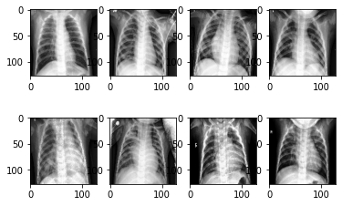

```python
# Show sample images in test images
for i in range(8):
  plt.subplot(2,4,i+1)
  plt.imshow(test_images[i])
```

**Data Pre-Processing**

```python
# Declare var for preprocessed images
preprocessed_trainImages = []
preprocessed_testImages = []
```

```python
# Iterate through and blur training images
for trainImage in train_images:
  blurTrainImage = cv2.GaussianBlur(trainImage, (5,5),0)
  preprocessed_trainImages.append(blurTrainImage)
```

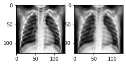

```python
# Show sample of training image and training image that is blurred
# Original Image
plt.subplot(1,3,1); plt.imshow(trainImage)
# Blurred Image
plt.subplot(1,3,2); plt.imshow(blurTrainImage)
```

```python
# Iterate through and blur the testing images
for testImage in test_images:
  blurTestimage = cv2.GaussianBlur(testImage, (5,5),0)
  preprocessed_testImages.append(blurTestimage)
```

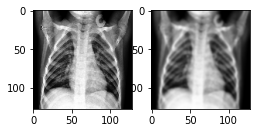

```python
# Show sample of testing image and testing image that is blurred
# Original Image
plt.subplot(1,3,1); plt.imshow(testImage)
# Blurred Image
plt.subplot(1,3,2); plt.imshow(blurTestimage)
```

```python
# Convert to array
preprocessed_trainImages_array = np.asarray(preprocessed_trainImages)
preprocessed_testImages_array = np.asarray(preprocessed_testImages)
```

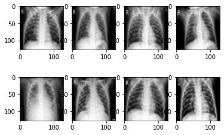

```python
# Show sample of the training images
for i in range(8):
  plt.subplot(2,4,i+1)
  plt.imshow(preprocessed_trainImages_array[i])
```

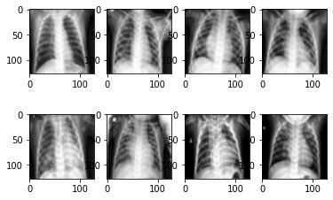

```python
# Show sample of the testing images
for i in range(8):
  plt.subplot(2,4,i+1)
  plt.imshow(preprocessed_testImages_array[i])
```

```python
# Normalize the training image data
preprocessed_trainImages_array = preprocessed_trainImages_array/255
```

```python
# Normalize the testing image data
preprocessed_testImages_array = preprocessed_testImages_array/255
```

**Make Data Compatible**

```python
# Utilize Label Binarizer to convert to one hot vectors
lb_train = LabelBinarizer()
y_train = lb_train.fit_transform(train_labels)
```

```python
y_train[0]
```

```
array([0, 0, 1])
```

```python
# Utilize Label Binarizer to convert to one hot vectors
lb_test = LabelBinarizer()
y_test = lb_test.fit_transform(test_labels)
```

```python
y_test[0]
```

```
array([0, 0, 1])
```

```python
# Check initial shapes
print(preprocessed_trainImages_array.shape)
print(preprocessed_testImages_array.shape)
print(y_train.shape)
print(y_test.shape)
```

```
(251, 128, 128, 3)
(66, 128, 128, 3)
(251, 3)
(66, 3)
```

```python
# Reshape for Keras models
X_train = preprocessed_trainImages_array.reshape(preprocessed_trainImages_array.shape[0],128,128,3)
X_test = preprocessed_testImages_array.reshape(preprocessed_testImages_array.shape[0],128,128,3)
```

```python
# Verify shape after reshaping - looks like the data was already compatible with Karas.
print(X_train.shape)
print(X_test.shape)
print(y_train.shape)
print(y_test.shape)
```

```
(251, 128, 128, 3)
(66, 128, 128, 3)
(251, 3)
(66, 3)
```

**Build CNN**

```python
# Set the CNN Model
batch_size = None

model = models.Sequential()
model.add(layers.Conv2D(32, (5,5), padding='same', activation="relu", input_shape=(128,128,3)))
model.add(layers.BatchNormalization())
model.add(layers.MaxPooling2D((2,2)))
model.add(layers.Dropout(0.2))
model.add(layers.Conv2D(64, (5,5), padding='same', activation="relu"))
model.add(layers.BatchNormalization())
model.add(layers.MaxPooling2D((2,2)))
model.add(layers.Dropout(0.3))
model.add(layers.Conv2D(64, (3,3), padding='same', activation="relu"))
model.add(layers.BatchNormalization())
model.add(layers.MaxPooling2D((2,2)))
model.add(layers.Dropout(0.4))
model.add(layers.Conv2D(64, (3,3), padding='same', activation="relu"))
model.add(layers.BatchNormalization())
model.add(layers.MaxPooling2D((2,2)))
model.add(layers.Dropout(0.5))

model.add(layers.GlobalMaxPooling2D())
model.add(layers.Dense(256, activation="relu"))
model.add(layers.Dropout(0.5))
model.add(layers.Dense(3, activation="softmax"))
model.summary()
```

```
Model: "sequential_1"
_________________________________________________________________
Layer (type)                 Output Shape              Param #
=================================================================
conv2d_4 (Conv2D)            (None, 128, 128, 32)      2432
_________________________________________________________________
batch_normalization_4 (Batch (None, 128, 128, 32)      128
_________________________________________________________________
max_pooling2d_4 (MaxPooling2 (None, 64, 64, 32)        0
_________________________________________________________________
dropout_5 (Dropout)          (None, 64, 64, 32)        0
_________________________________________________________________
conv2d_5 (Conv2D)            (None, 64, 64, 64)        51264
_________________________________________________________________
batch_normalization_5 (Batch (None, 64, 64, 64)        256
_________________________________________________________________
max_pooling2d_5 (MaxPooling2 (None, 32, 32, 64)        0
_________________________________________________________________
dropout_6 (Dropout)          (None, 32, 32, 64)        0
_________________________________________________________________
conv2d_6 (Conv2D)            (None, 32, 32, 64)        36928
_________________________________________________________________
batch_normalization_6 (Batch (None, 32, 32, 64)        256
_________________________________________________________________
max_pooling2d_6 (MaxPooling2 (None, 16, 16, 64)        0
_________________________________________________________________
dropout_7 (Dropout)          (None, 16, 16, 64)        0
_________________________________________________________________
conv2d_7 (Conv2D)            (None, 16, 16, 64)        36928
_________________________________________________________________
batch_normalization_7 (Batch (None, 16, 16, 64)        256
_________________________________________________________________
max_pooling2d_7 (MaxPooling2 (None, 8, 8, 64)          0
_________________________________________________________________
dropout_8 (Dropout)          (None, 8, 8, 64)          0
_________________________________________________________________
global_max_pooling2d_1 (Glob (None, 64)                0
_________________________________________________________________
dense_2 (Dense)              (None, 256)               16640
_________________________________________________________________
dropout_9 (Dropout)          (None, 256)               0
_________________________________________________________________
dense_3 (Dense)              (None, 3)                 771
=================================================================
Total params: 145,859
Trainable params: 145,411
Non-trainable params: 448
_________________________________________________________________
```

```python
# Define the optimizer and the loss function and compile the model as needed
optimizer = Adam(learning_rate=0.001,
                 beta_1=0.9,
                 beta_2=0.999,
                 epsilon=1e-07,
                 amsgrad=False,
                 name='Adam')
model.compile(optimizer = optimizer, loss="categorical_crossentropy", metrics=["accuracy"])
```

```python
# Split testing and validation data
random_seed = 7
X_test, X_val, y_test, y_val = train_test_split(X_test, y_test, test_size = 0.5, random_state = random_seed)
```

```python
print(X_test.shape)
print(X_val.shape)
print(y_test.shape)
print(y_val.shape)
```

```
(16, 128, 128, 3)
(17, 128, 128, 3)
(16, 3)
(17, 3)
```

```python
#
history = model.fit(X_train, y_train, epochs = 200, validation_data = (X_val,y_val),batch_size = batch_size)
```

**Fit and Evaluate Model & Print Confusion Matrix**

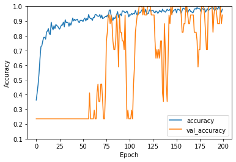

```python
# Plot out the difference between accuracy and val accuracy
plt.plot(history.history['accuracy'], label='accuracy')
plt.plot(history.history['val_accuracy'], label = 'val_accuracy')
plt.xlabel('Epoch')
plt.ylabel('Accuracy')
plt.ylim([0.1, 1])
plt.legend(loc='lower right');
```

```python
# Evaluate the model
score = model.evaluate(X_test, y_test, verbose=0, batch_size = 38)
print('Test loss:', score[0])
print('Test accuracy:', score[1])
```

```
Test loss: 0.2251356691122055
Test accuracy: 0.9375
```

Analysis: ran through multiple epoch counts and got really low test accuracy and things were not showing up like they should have on the chart or the expected numbers. Kept gradually bumping the epochs up to get the number above.

```python
# Predict values from the validation dataset
Y_prediction = model.predict(X_val)
# Convert predictions to hot vectors
result = np.argmax(Y_prediction, axis=1)
# Convert validation to hot vectors
Y_true = np.argmax(y_val, axis=1)
```

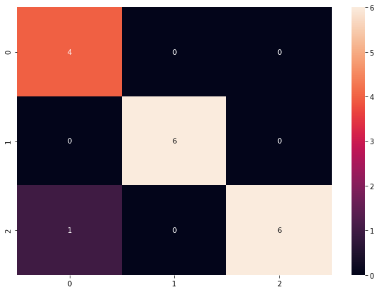

```python
# Draw the confusion matrix
covid_confusion_matrix = confusion_matrix(Y_true, result)

dataframe_cm = pd.DataFrame(covid_confusion_matrix, index = [i for i in range(0, 3)],
                  columns = [i for i in range(0, 3)])
plt.figure(figsize = (10,7))
sns.heatmap(dataframe_cm, annot=True, fmt='g');
```

It shows that there was an image that was mis catagorized with a predicted label of 0 and a true label of 2.

**Visualize Predictions**

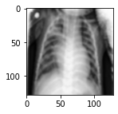

```
Predicted Label 0
True Label 2
```

```python
# Visualize images and predicted vs true on incorrect prediction
plt.figure(figsize=(2,2))
plt.imshow(X_test[0], cmap="gray")
plt.show()
print('Predicted Label', np.argmax(model.predict(X_test[0].reshape(1,128,128,3))))
print('True Label', np.argmax(y_test[0]))
```

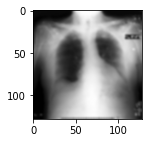

```
Predicted Label 0
True Label 0
```

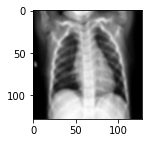

```
Predicted Label 1
True Label 1
```

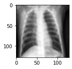

```
Predicted Label 2
True Label 2
```

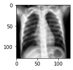

```
Predicted Label 1
True Label 1
```

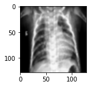

```
Predicted Label 2
True Label 2
```

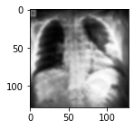

```
Predicted Label 0
True Label 0
```

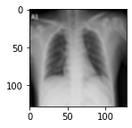

```
Predicted Label 0
True Label 0
```

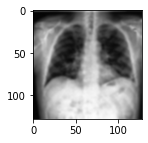

```
Predicted Label 0
True Label 0
```

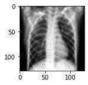

```
Predicted Label 1
True Label 1
```

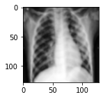

```
Predicted Label 2
True Label 2
```

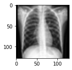

```
Predicted Label 1
True Label 1
```

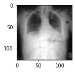

```
Predicted Label 0
True Label 0
```

[3 more figures not shown]

```
Predicted Label 0
True Label 0
```

```python
# Visualize images and predicted vs true for correct prediction
plt.figure(figsize=(2,2))
plt.imshow(X_test[1], cmap="gray")
plt.show()
print('Predicted Label', np.argmax(model.predict(X_test[1].reshape(1,128,128,3))))
print('True Label', np.argmax(y_test[1]))

plt.figure(figsize=(2,2))
plt.imshow(X_test[2], cmap="gray")
plt.show()
print('Predicted Label', np.argmax(model.predict(X_test[2].reshape(1,128,128,3))))
print('True Label', np.argmax(y_test[2]))

plt.figure(figsize=(2,2))
plt.imshow(X_test[3], cmap="gray")
plt.show()
print('Predicted Label', np.argmax(model.predict(X_test[3].reshape(1,128,128,3))))
print('True Label', np.argmax(y_test[3]))

plt.figure(figsize=(2,2))
plt.imshow(X_test[4], cmap="gray")
plt.show()
print('Predicted Label', np.argmax(model.predict(X_test[4].reshape(1,128,128,3))))
print('True Label', np.argmax(y_test[4]))

plt.figure(figsize=(2,2))
plt.imshow(X_test[5], cmap="gray")
plt.show()
print('Predicted Label', np.argmax(model.predict(X_test[5].reshape(1,128,128,3))))
print('True Label', np.argmax(y_test[5]))

plt.figure(figsize=(2,2))
plt.imshow(X_test[6], cmap="gray")
plt.show()
print('Predicted Label', np.argmax(model.predict(X_test[6].reshape(1,128,128,3))))
print('True Label', np.argmax(y_test[6]))

plt.figure(figsize=(2,2))
plt.imshow(X_test[7], cmap="gray")
plt.show()
print('Predicted Label', np.argmax(model.predict(X_test[7].reshape(1,128,128,3))))
print('True Label', np.argmax(y_test[7]))

plt.figure(figsize=(2,2))
plt.imshow(X_test[8], cmap="gray")
plt.show()
print('Predicted Label', np.argmax(model.predict(X_test[8].reshape(1,128,128,3))))
print('True Label', np.argmax(y_test[8]))

plt.figure(figsize=(2,2))
plt.imshow(X_test[9], cmap="gray")
plt.show()
print('Predicted Label', np.argmax(model.predict(X_test[9].reshape(1,128,128,3))))
print('True Label', np.argmax(y_test[9]))

plt.figure(figsize=(2,2))
plt.imshow(X_test[10], cmap="gray")
plt.show()
print('Predicted Label', np.argmax(model.predict(X_test[10].reshape(1,128,128,3))))
print('True Label', np.argmax(y_test[10]))

plt.figure(figsize=(2,2))
plt.imshow(X_test[11], cmap="gray")
plt.show()
print('Predicted Label', np.argmax(model.predict(X_test[11].reshape(1,128,128,3))))
print('True Label', np.argmax(y_test[11]))

plt.figure(figsize=(2,2))
plt.imshow(X_test[12], cmap="gray")
plt.show()
print('Predicted Label', np.argmax(model.predict(X_test[12].reshape(1,128,128,3))))
print('True Label', np.argmax(y_test[12]))

plt.figure(figsize=(2,2))
plt.imshow(X_test[13], cmap="gray")
plt.show()
print('Predicted Label', np.argmax(model.predict(X_test[13].reshape(1,128,128,3))))
print('True Label', np.argmax(y_test[13]))

plt.figure(figsize=(2,2))
plt.imshow(X_test[14], cmap="gray")
plt.show()
print('Predicted Label', np.argmax(model.predict(X_test[14].reshape(1,128,128,3))))
print('True Label', np.argmax(y_test[14]))

plt.figure(figsize=(2,2))
plt.imshow(X_test[15], cmap="gray")
plt.show()
print('Predicted Label', np.argmax(model.predict(X_test[15].reshape(1,128,128,3))))
print('True Label', np.argmax(y_test[15]))
```